# R Notebook

Start by cleaning the data. Taking only ani depressants. Removing all use of medication prior to index day. Then do hazard analysis with age (make categorical, gender, marital statues, comorbidity)

```r
# load data
library(tidyverse)
library(jtools)
vaDat <- read_csv('/home/or/Dropbox/postdoc/Yale/va_data/MED_Drop.csv')
vaDatclean <- vaDat
# remove more than 365 psychotherapies
vaDatclean$MHTOTALLc <- ifelse((vaDatclean$MHTOTALL > 365), (vaDatclean$MHTOTALLc = 365), (vaDatclean$MHTOTALLc = vaDatclean$MHTOTALL))

# set index date
a = '01/01/1960'
vaDatclean$PTSDINDr = as.Date(as.character(a), format = '%d/%m/%Y') + vaDatclean$PTSDIND
# Now take only patients who recieved medications.
onlyMed_dat <- subset(vaDatclean, vaDatclean$PMEDRX==1)
# set number of days from index day to drop out
vaDatclean$totalDays <- as.Date(as.character(vaDatclean$MHDROPD),format = '%m/%d/%Y')  - as.Date(vaDatclean$PTSDINDr,format = '%Y/%m/%d')
head(vaDatclean)
```

| PTSDIND | MHPRE_DTE | MHPST_DTE | MHDROPD | MHDROP | OBSRV_PERIOD | MHTOTALL | POSTDXTOT | MHFUFRST | MHPRETOT | MHPOSTYTOT | MHPTSDTOT | MSPRE_DTE | MSPOST_DTE | MSTOTPRE | MSTOTPOST | INDPSY | GRPPSY | FAMPSY | PSYCTHR | TIMEVST | MONTH2 | MONTH4 | MONTH6 | MONTH12 | VATXM | REAL8VST | DEMENT_ALZ | ALC | DRUG | … |
| --- | --- | --- | --- | --- | --- | --- | --- | --- | --- | --- | --- | --- | --- | --- | --- | --- | --- | --- | --- | --- | --- | --- | --- | --- | --- | --- | --- | --- | --- | --- |
| 18932 | NA | 12/1/2011 | 9/27/2012 | 1 | 9/27/2012 | 89 | 60 | 30 | 0 | 88 | 60 | NA | 12/13/2011 | NA | 12 | 32 | 8 | 0 | 40 | 7.615385 | 1 | 1 | 1 | 0 | 1 | 56 | 0 | 0 | 0 | … |
| 18961 | NA | 1/26/2012 | 2/29/2012 | 1 | 2/29/2012 | 4 | 2 | 57 | 0 | 4 | 2 | NA | 1/20/2012 | NA | 9 | 2 | 0 | 0 | 2 | 34.000000 | 1 | 0 | 0 | 0 | 0 | NA | 0 | 0 | 0 | … |
| 17520 | 12/26/2006 | 12/28/2007 | 2/4/2008 | 1 | 2/4/2008 | 8 | 0 | 8 | 7 | 10 | 0 | 5/8/2007 | 1/14/2008 | 5 | 7 | 8 | 0 | 0 | 8 | 102.428571 | 1 | 1 | 1 | 0 | 0 | NA | 0 | 0 | 0 | … |
| 18996 | NA | NA | NA | 0 | 1/3/2013 | 0 | 0 | NA | 0 | 0 | 0 | 5/11/2011 | 1/27/2012 | 7 | 10 | 3 | 0 | 0 | 3 | 352.000000 | 0 | 0 | 0 | 0 | 0 | NA | 0 | 0 | 0 | … |
| 17741 | NA | NA | NA | 0 | 7/28/2008 | 0 | 0 | NA | 0 | 0 | 0 | 9/6/2007 | 8/6/2008 | 28 | 14 | NA | NA | NA | NA | NA | 0 | 0 | 0 | 0 | 0 | NA | 0 | 0 | 0 | … |
| 17784 | NA | 9/12/2008 | NA | 0 | 9/9/2009 | 40 | 39 | 3 | 0 | 38 | 37 | NA | NA | NA | NA | 25 | 7 | 0 | 32 | 26.225806 | 1 | 1 | 1 | 1 | 1 | 65 | 0 | 0 | 0 | … |

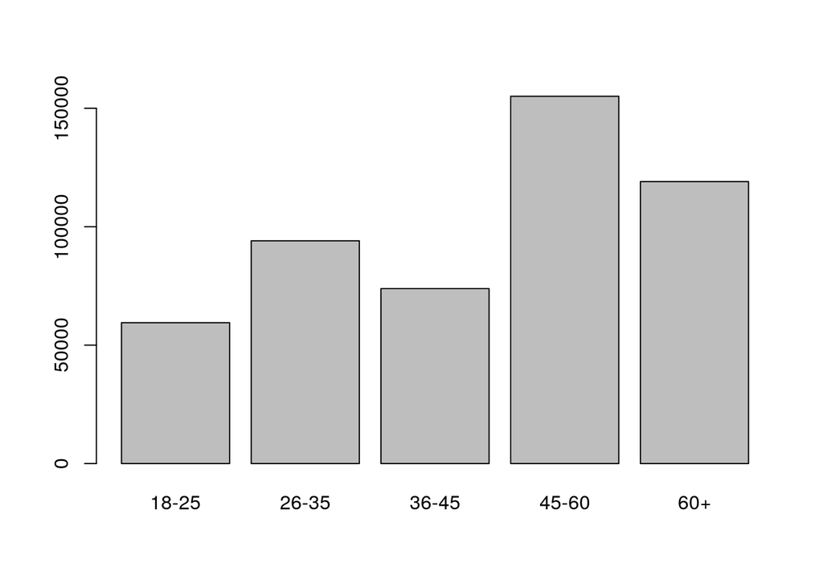

```r
# create a few variables before stratification
# Race
vaDatclean$race <- dplyr::case_when(vaDatclean$BLACK==1 ~ "Black",vaDatclean$WHITE==1 ~ "White", vaDatclean$HISPANIC==1 ~ "Hispanic", vaDatclean$ASIAN ==1 ~ "Asian", TRUE ~ "Other")
vaDatclean$race <- factor(vaDatclean$race)
# change levels white will be first
vaDatclean$race <- relevel(vaDatclean$race, "White")

# turn age to categorical
vaDatclean$ageCat <- cut(vaDatclean$AGE_OCT01, breaks = c(15, 25, 35, 45, 60, 90), labels = c("18-25", "26-35", "36-45", "45-60", "60+"))
plot(vaDatclean$ageCat)
```

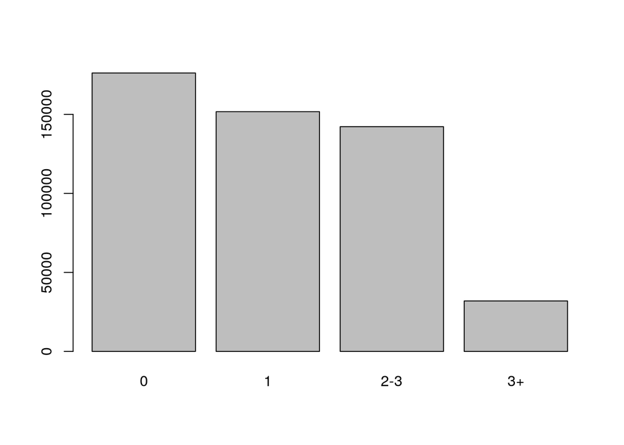

```r
# check comorbidity
vaDatclean$sumComorbid <- vaDatclean$DEMENT_ALZ + vaDatclean$ALC + vaDatclean$DRUG + vaDatclean$SCHIZOPHRENIA + vaDatclean$OTHERPSYCHOSIS + vaDatclean$BIPOLAR + vaDatclean$MAJORAFFECT + vaDatclean$OTHERDEP + vaDatclean$ANXIETY + vaDatclean$ADJUSTMENT + vaDatclean$PERSONALITY + vaDatclean$BORDERLINE
#antiDP_dat$comorbid <- dplyr::case_when(antiDP_dat$DEMENT_ALZ!=0 ~ "Dementia", antiDP_dat$ALC !=0 ~"Alcohol", )
vaDatclean$MARRIED <- factor(vaDatclean$MARRIED)

vaDatclean$FEMALE <- factor(vaDatclean$FEMALE)
vaDatclean$VATXM <- factor(vaDatclean$VATXM) #, labels = c("Yes", "No"))
# Creating Psychotherapy 0 - none or 1 = exist
vaDatclean$PSYCTR <- dplyr::case_when(vaDatclean$INDPSY >1 | vaDatclean$GRPPSY >1 | vaDatclean$FAMPSY >1 ~ "yes", TRUE ~ "no")
vaDatclean$PSYCTR <- factor(vaDatclean$PSYCTR)
vaDatclean$PSYCTR <- relevel(vaDatclean$PSYCTR, "yes")

vaDatclean$sumComorbidfactor <- cut(vaDatclean$sumComorbid, breaks = c(-1,0,1,3,15), labels = c("0","1", "2-3","3+"))
plot(vaDatclean$sumComorbidfactor)
```

```r
vaDatclean$ANXfactor <- factor(vaDatclean$ANXIETY)
vaDatclean$URBAN_RURAL <- factor(vaDatclean$URBAN_RURAL)
vaDatclean$MAJORAFFECT <- factor(vaDatclean$MAJORAFFECT)


vaDatclean$OEFOIF <- factor(vaDatclean$OEFOIF)

vaDatclean$ADRXN_true <- case_when(vaDatclean$ADRXN > 0 ~ 1, TRUE ~0)
vaDatclean$APSRXN_true <- case_when(vaDatclean$APSRXN >0 ~ 1, TRUE ~0)
vaDatclean$AXSEDHPRXN_true <- case_when(vaDatclean$AXSEDHPRXN >0 ~ 1, TRUE ~0)
vaDatclean$STIMRXN_true <- case_when(vaDatclean$STIMRXN > 0 ~ 1, TRUE ~ 0)
vaDatclean$ACVMSRXN_true <- case_when(vaDatclean$ACVMSRXN > 0 ~ 1, TRUE ~ 0)
vaDatclean$LIRXN_true <- case_when(vaDatclean$LIRXN > 0 ~ 1, TRUE ~ 0)

vaDatclean$sumMed <- vaDatclean$LIRXN_true + vaDatclean$ACVMSRXN_true + vaDatclean$STIMRXN_true + vaDatclean$AXSEDHPRXN_true + vaDatclean$APSRXN_true + vaDatclean$ADRXN_true
vaDatclean$sumMedCat <- factor(case_when(vaDatclean$sumMed==1 ~ '1', vaDatclean$sumMed == 2 ~ "2", vaDatclean$sumMed >= 3 ~ "3+"))

# create a censore variable who survived more than 30 days
vaDatclean$MONTH1 <- case_when(vaDatclean$totalDays <= 30 ~ 1, TRUE ~ 0)
```

Lets take just medicated patients, before stratify to different groups of medication.

```r
# take just medicated patients.
medicatedVa_dat <- filter(vaDatclean, PMEDRX==1)
head(medicatedVa_dat)
```

| PTSDIND | MHPRE_DTE | MHPST_DTE | MHDROPD | MHDROP | OBSRV_PERIOD | MHTOTALL | POSTDXTOT | MHFUFRST | MHPRETOT | MHPOSTYTOT | MHPTSDTOT | MSPRE_DTE | MSPOST_DTE | MSTOTPRE | MSTOTPOST | INDPSY | GRPPSY | FAMPSY | PSYCTHR | TIMEVST | MONTH2 | MONTH4 | MONTH6 | MONTH12 | VATXM | REAL8VST | DEMENT_ALZ | ALC | DRUG | … |
| --- | --- | --- | --- | --- | --- | --- | --- | --- | --- | --- | --- | --- | --- | --- | --- | --- | --- | --- | --- | --- | --- | --- | --- | --- | --- | --- | --- | --- | --- | --- |
| 18932 | NA | 12/1/2011 | 9/27/2012 | 1 | 9/27/2012 | 89 | 60 | 30 | 0 | 88 | 60 | NA | 12/13/2011 | NA | 12 | 32 | 8 | 0 | 40 | 7.615385 | 1 | 1 | 1 | 0 | 1 | 56 | 0 | 0 | 0 | … |
| 18961 | NA | 1/26/2012 | 2/29/2012 | 1 | 2/29/2012 | 4 | 2 | 57 | 0 | 4 | 2 | NA | 1/20/2012 | NA | 9 | 2 | 0 | 0 | 2 | 34.000000 | 1 | 0 | 0 | 0 | 0 | NA | 0 | 0 | 0 | … |
| 17520 | 12/26/2006 | 12/28/2007 | 2/4/2008 | 1 | 2/4/2008 | 8 | 0 | 8 | 7 | 10 | 0 | 5/8/2007 | 1/14/2008 | 5 | 7 | 8 | 0 | 0 | 8 | 102.428571 | 1 | 1 | 1 | 0 | 0 | NA | 0 | 0 | 0 | … |
| 18996 | NA | NA | NA | 0 | 1/3/2013 | 0 | 0 | NA | 0 | 0 | 0 | 5/11/2011 | 1/27/2012 | 7 | 10 | 3 | 0 | 0 | 3 | 352.000000 | 0 | 0 | 0 | 0 | 0 | NA | 0 | 0 | 0 | … |
| 18905 | 6/8/2011 | 12/28/2011 | 5/14/2012 | 1 | 5/14/2012 | 5 | 4 | 84 | 5 | 4 | 3 | 10/20/2010 | 10/6/2011 | 18 | 18 | 7 | 0 | 0 | 7 | 56.833333 | 1 | 1 | 1 | 0 | 0 | NA | 0 | 0 | 0 | … |
| 18939 | NA | 12/2/2011 | 2/1/2012 | 1 | 2/1/2012 | 3 | 1 | 24 | 0 | 4 | 1 | 11/17/2010 | 11/25/2011 | 6 | 10 | 1 | 0 | 0 | 1 | NA | 1 | 1 | 1 | 0 | 0 | NA | 0 | 0 | 0 | … |

Lets look at some descriptives

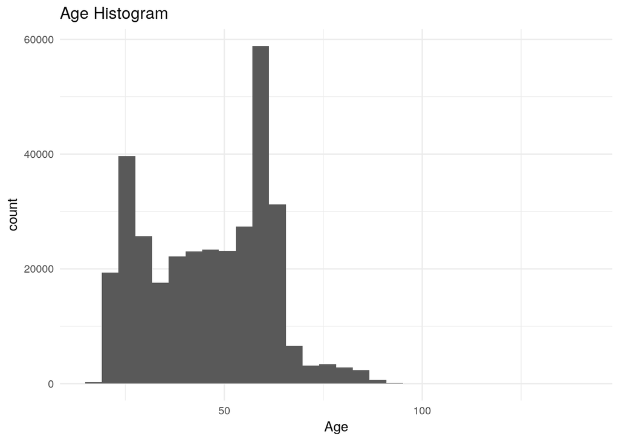

```r
# plot age
ggplot(medicatedVa_dat, aes(x=medicatedVa_dat$AGE_OCT01)) + geom_histogram() + xlab("Age") + stat_bin(bins=30) + theme_minimal() + ggtitle("Age Histogram")
```

```r
summary(medicatedVa_dat$MARRIED)
```

```
##      0      1
## 170306 160466
```

```r
table(medicatedVa_dat$FEMALE)
```

```
##
##      0      1
## 298475  32297
```

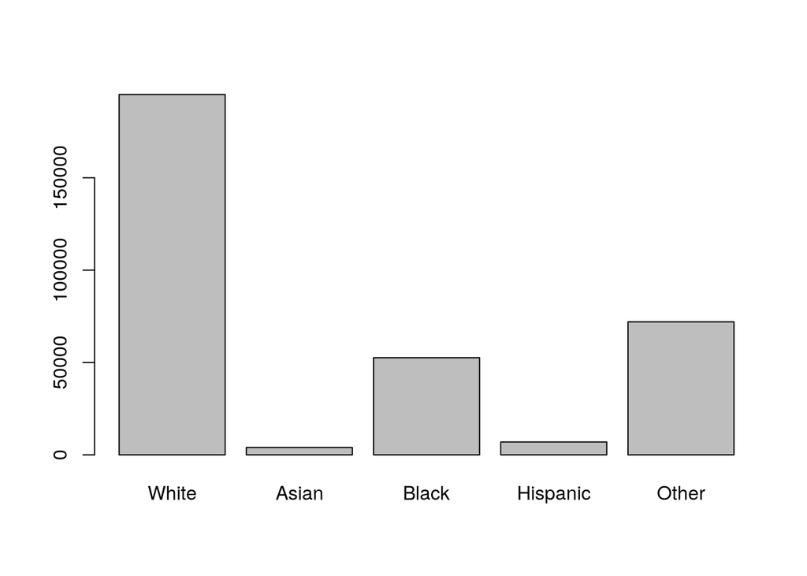

```r
plot(medicatedVa_dat$race)
```

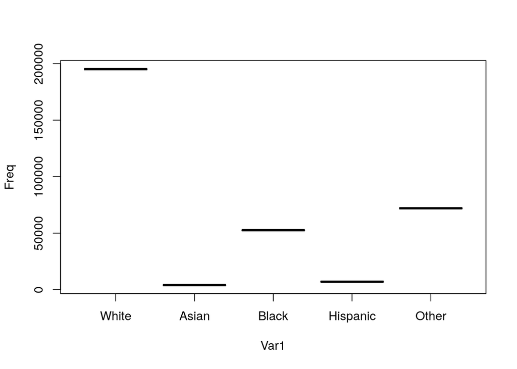

```r
g <- data.frame(table(medicatedVa_dat$race))
plot(g)
```

```r
table(g)
```

```
##           Freq
## Var1       4023 6993 52601 72029 195126
##   White       0    0     0     0      1
##   Asian       1    0     0     0      0
##   Black       0    0     1     0      0
##   Hispanic    0    1     0     0      0
##   Other       0    0     0     1      0
```

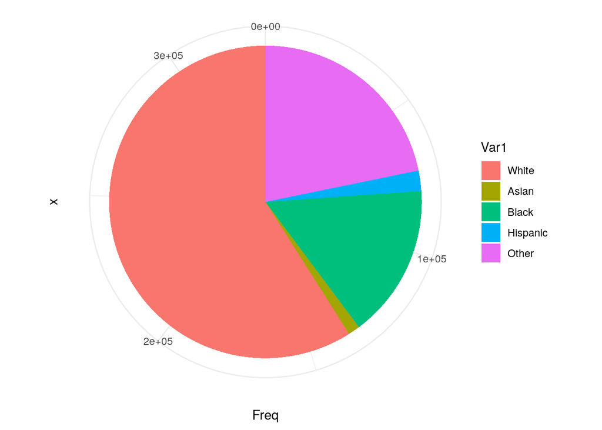

```r
ggplot(g, aes(x= "",y=Freq, fill = Var1)) + geom_bar(width = 14, stat = "identity") + coord_polar("y") + theme_minimal()
```

```r
table(medicatedVa_dat$sumMed)
```

```
##
##      1      2      3      4      5      6
## 155371 111059  47593  14983   1680     86
```

```r
# now we clean data
# take only anti depressant without any medication before index day
antiDP_dat <- dplyr::filter(vaDatclean, !is.na(ADRXN) & is.na(PREADRX) & is.na(PREAPRX) & is.na(PREAXRX) & is.na(PRESTIRX) & is.na(PREACRX) & is.na(PRELIRX) & is.na(PREOPRX) & is.na(PREPRZRX))
head(antiDP_dat)
```

| PTSDIND | MHPRE_DTE | MHPST_DTE | MHDROPD | MHDROP | OBSRV_PERIOD | MHTOTALL | POSTDXTOT | MHFUFRST | MHPRETOT | MHPOSTYTOT | MHPTSDTOT | MSPRE_DTE | MSPOST_DTE | MSTOTPRE | MSTOTPOST | INDPSY | GRPPSY | FAMPSY | PSYCTHR | TIMEVST | MONTH2 | MONTH4 | MONTH6 | MONTH12 | VATXM | REAL8VST | DEMENT_ALZ | ALC | DRUG | … |
| --- | --- | --- | --- | --- | --- | --- | --- | --- | --- | --- | --- | --- | --- | --- | --- | --- | --- | --- | --- | --- | --- | --- | --- | --- | --- | --- | --- | --- | --- | --- |
| 18932 | NA | 12/1/2011 | 9/27/2012 | 1 | 9/27/2012 | 89 | 60 | 30 | 0 | 88 | 60 | NA | 12/13/2011 | NA | 12 | 32 | 8 | 0 | 40 | 7.615385 | 1 | 1 | 1 | 0 | 1 | 56 | 0 | 0 | 0 | … |
| 18961 | NA | 1/26/2012 | 2/29/2012 | 1 | 2/29/2012 | 4 | 2 | 57 | 0 | 4 | 2 | NA | 1/20/2012 | NA | 9 | 2 | 0 | 0 | 2 | 34.000000 | 1 | 0 | 0 | 0 | 0 | NA | 0 | 0 | 0 | … |
| 18996 | NA | NA | NA | 0 | 1/3/2013 | 0 | 0 | NA | 0 | 0 | 0 | 5/11/2011 | 1/27/2012 | 7 | 10 | 3 | 0 | 0 | 3 | 352.000000 | 0 | 0 | 0 | 0 | 0 | NA | 0 | 0 | 0 | … |
| 18939 | NA | 12/2/2011 | 2/1/2012 | 1 | 2/1/2012 | 3 | 1 | 24 | 0 | 4 | 1 | 11/17/2010 | 11/25/2011 | 6 | 10 | 1 | 0 | 0 | 1 | NA | 1 | 1 | 1 | 0 | 0 | NA | 0 | 0 | 0 | … |
| 17667 | NA | 6/13/2008 | 12/17/2008 | 1 | 12/17/2008 | 5 | 5 | 29 | 0 | 6 | 6 | 5/31/2007 | 5/15/2009 | 1 | 1 | 8 | 0 | 0 | 8 | 100.000000 | 1 | 1 | 1 | 1 | 0 | NA | 0 | 0 | 0 | … |
| 18297 | NA | NA | NA | 0 | 2/4/2011 | 0 | 0 | NA | 0 | 0 | 0 | NA | 8/2/2010 | NA | 9 | NA | NA | NA | NA | NA | 1 | 1 | 1 | 1 | 0 | NA | 0 | 0 | 0 | … |

```r
# just to check how much people using anti depressants.
antiDP <- filter(vaDatclean, !is.na(ADRXN))
294224/330772
```

```
## [1] 0.889507
```

Now lets look at the drugs

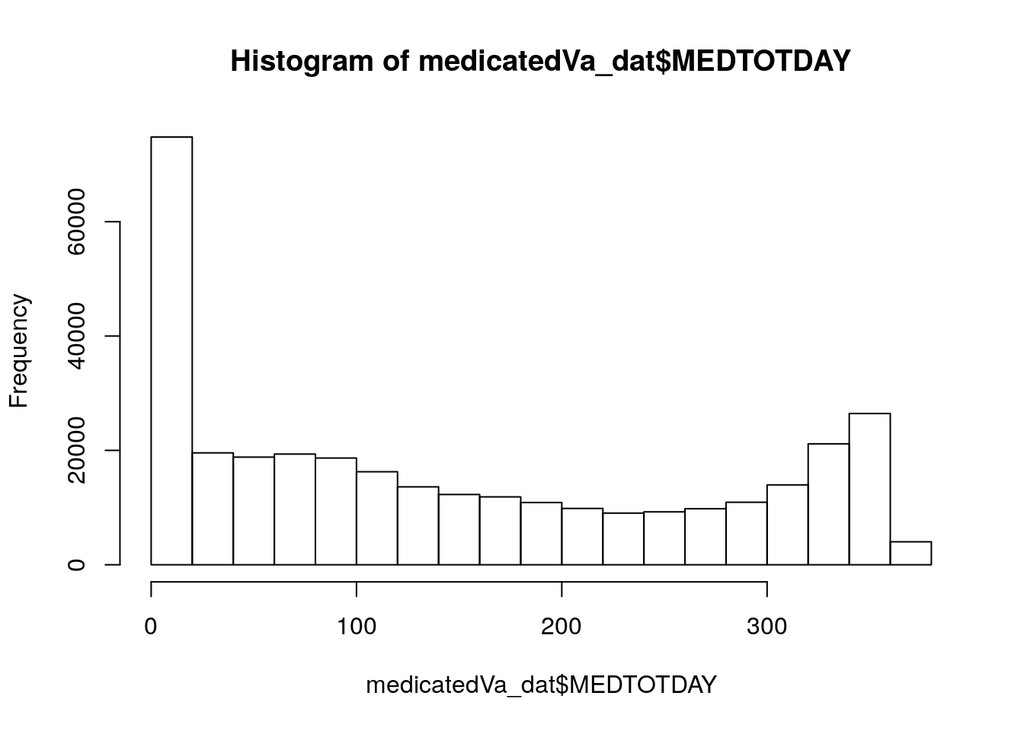

```r
# whats the average drug usage?
drugeUsage<- table(medicatedVa_dat$ADDAY)#, antiDP_dat$APSDAY, antiDP_dat$AXDAY, vaDatclean$STIMDAY)
hist(medicatedVa_dat$MEDTOTDAY)
```

```r
# many patients drop out fast.
# lets see how many we have after 30 days of use
drugeMore30 <- filter(medicatedVa_dat, MEDTOTDAY >= 30)
247083/330772
```

```
## [1] 0.7469889
```

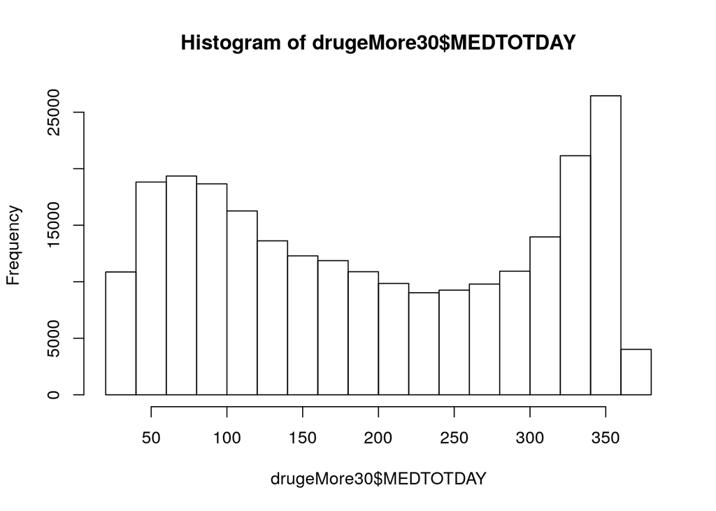

```r
# only 74.6% of the people survive the first 30 days.
hist(drugeMore30$MEDTOTDAY)
```

```r
drugLess30 <- filter(medicatedVa_dat, MEDTOTDAY  <= 30)
mean(medicatedVa_dat$ADDAY, na.rm=TRUE)
```

```
## [1] 120.1322
```

```r
sd(antiDP_dat$ADDAY)
```

```
## [1] 111.1598
```

```r
median(medicatedVa_dat$ADDAY, na.rm=TRUE)
```

```
## [1] 84
```

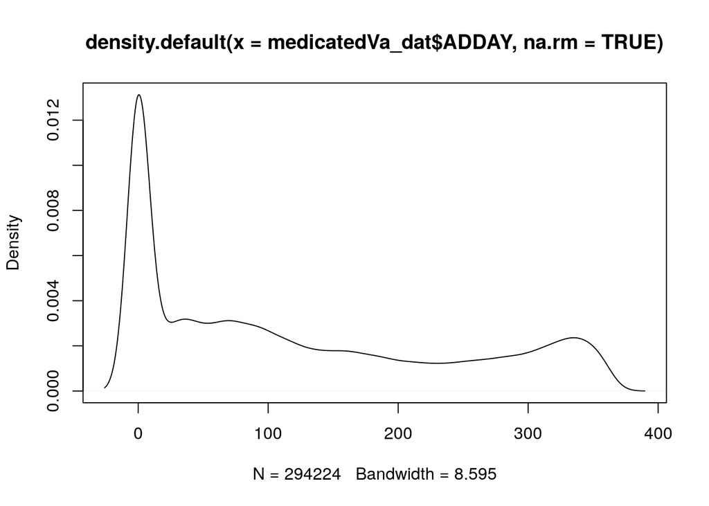

```r
plot(density(medicatedVa_dat$ADDAY, na.rm=TRUE) )
```

So - after 30 days we see major drop out. We will start by focusing on that time period.

```r
# first create survival model
# drugless30 includes 84,575
84575/330772
```

```
## [1] 0.2556897
```

```r
library(survival)
library(survminer)
drugLess30$psycOne <- factor(case_when(drugLess30$INDPSY >1 | drugLess30$GRPPSY >1 | drugLess30$FAMPSY >1 ~ "yes", TRUE ~ "no"))
drugLess30$psycOne <- relevel(drugLess30$psycOne, "yes")
surv_less30 <- Surv(time = drugLess30$MEDTOTDAY, event = drugLess30$MONTH1)
summary(surv_less30)
```

```
##       time            status
##  Min.   : 0.000   Min.   :0.0000
##  1st Qu.: 0.000   1st Qu.:0.0000
##  Median : 0.000   Median :0.0000
##  Mean   : 4.848   Mean   :0.1806
##  3rd Qu.: 5.000   3rd Qu.:0.0000
##  Max.   :30.000   Max.   :1.0000
```

```r
summary(drugLess30$MEDTOTDAY)
```

```
##    Min. 1st Qu.  Median    Mean 3rd Qu.    Max.
##   0.000   0.000   0.000   4.848   5.000  30.000
```

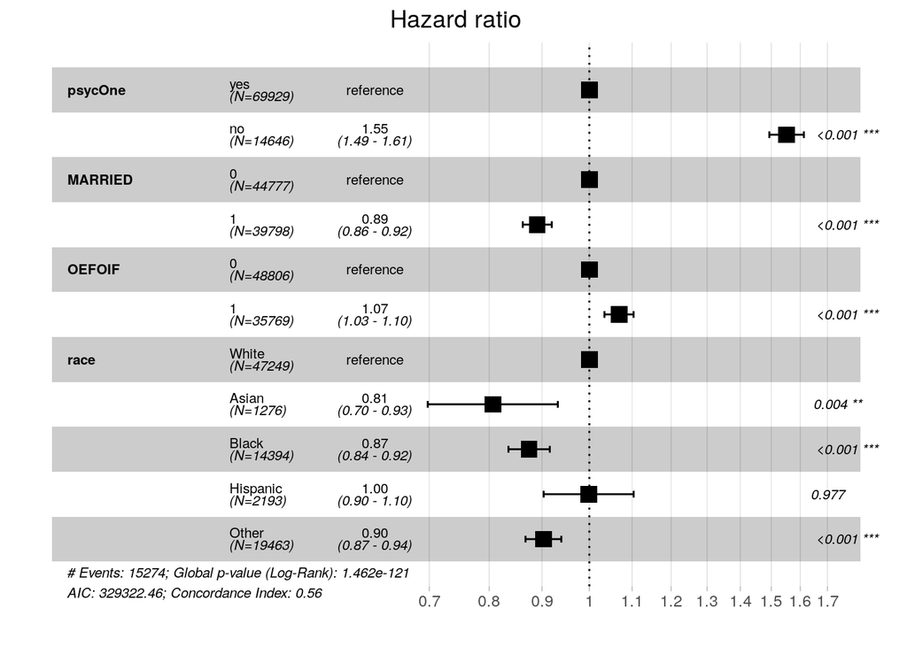

```r
# now cox analysis
fit.coxphLess30 <- coxph(surv_less30 ~ psycOne + MARRIED + OEFOIF + race ,
                   data = drugLess30)
ggforest(fit.coxphLess30, data = drugLess30)
```

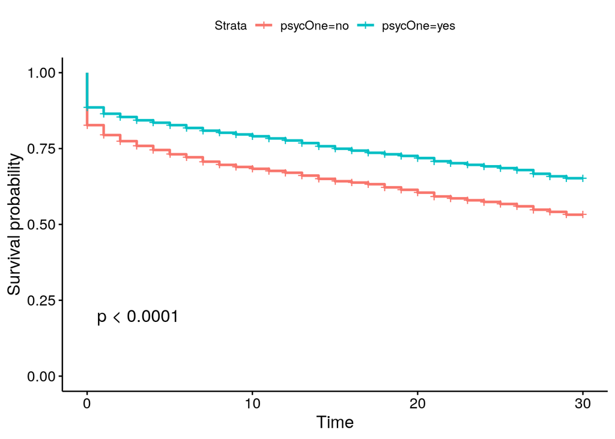

```r
# lets do survival analysis just with psychotherapy
fit1 <- survfit(surv_less30 ~ drugLess30$psycOne, data = drugLess30) # fit the analysis with gender
ggsurvplot(fit1, data = drugLess30, pval = TRUE)
```

```r
table(drugLess30$psycOne, drugLess30$MEDTOTDAY)
```

```
##
##           0     1     2     3     4     5     6     7     8     9    10
##   yes 45689  2763  1051  1009   768   648   667   718   583   463   480
##   no  10832   599   246   226   157   120   123   129   102    74    69
##
##          11    12    13    14    15    16    17    18    19    20    21
##   yes   534   507   661   929   735   541   571   592   560   757   939
##   no     79    86    96   137    90    78    63    90    78   108   131
##
##          22    23    24    25    26    27    28    29    30
##   yes   808   594   615   661   661   965  1399  1094   967
##   no     96    82    85    75    92   123   147   135    98
```

```r
mean(drugLess30$MEDTOTDAY[drugLess30$psycOne=='yes'])
```

```
## [1] 5.17432
```

Now we will create the same analysis, but for all patients under medication, and we will check the effect of more than one psychotherapy sessions (not more than 0)

```r
#
surv_all <- Surv(time = medicatedVa_dat$MEDTOTDAY, event = medicatedVa_dat$MHDROP)
summary(surv_all)
```

```
##       time           status
##  Min.   :  0.0   Min.   :0.0000
##  1st Qu.: 29.0   1st Qu.:0.0000
##  Median :118.0   Median :1.0000
##  Mean   :147.1   Mean   :0.6548
##  3rd Qu.:268.0   3rd Qu.:1.0000
##  Max.   :364.0   Max.   :1.0000
##  NA's   :179
```

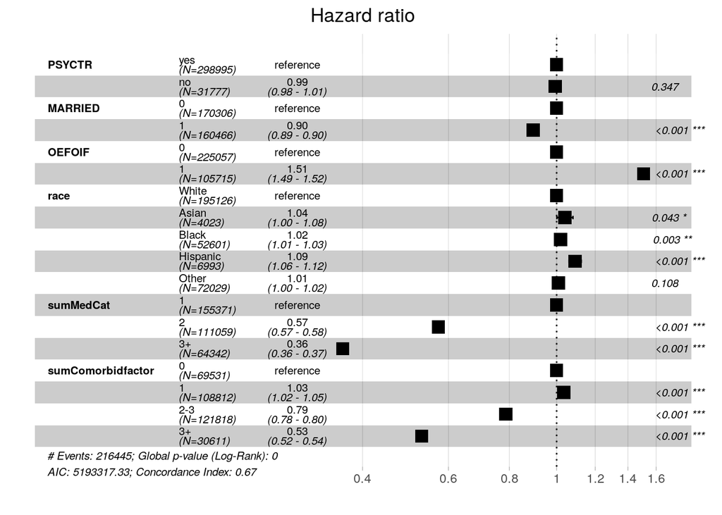

```r
medicatedVa_dat$psycOne <- factor(case_when(medicatedVa_dat$INDPSY >1 | medicatedVa_dat$GRPPSY >1 | medicatedVa_dat$FAMPSY >1 ~ "yes", TRUE ~ "no"))
medicatedVa_dat$psycOne <- relevel(medicatedVa_dat$psycOne, "yes")
# now cox analysis
fit.coxAll <- coxph(surv_all ~ PSYCTR + MARRIED + OEFOIF + race + sumMedCat + sumComorbidfactor,
                   data = medicatedVa_dat)
ggforest(fit.coxAll, data = medicatedVa_dat)
```

Now lets see the effect of psychotherapy.

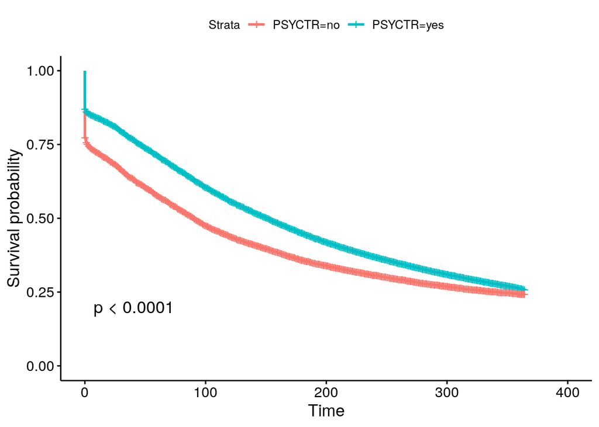

```r
fit_psych <- survfit(surv_all ~ medicatedVa_dat$PSYCTR, data = medicatedVa_dat) # fit the analysis with gender
#summary(fit1)
ggsurvplot(fit_psych, data = medicatedVa_dat, pval = TRUE)
```

```r
model30 <- glm(MONTH1 ~ PSYCTHR + MARRIED + AGE_OCT01 + race + sumComorbid + sumMed, data = medicatedVa_dat)
summary(model30)
```

```
##
## Call:
## glm(formula = MONTH1 ~ PSYCTHR + MARRIED + AGE_OCT01 + race +
##     sumComorbid + sumMed, data = medicatedVa_dat)
##
## Deviance Residuals:
##      Min        1Q    Median        3Q       Max
## -0.11282  -0.06536  -0.04525  -0.02092   1.06876
##
## Coefficients:
##                Estimate Std. Error t value Pr(>|t|)
## (Intercept)   1.482e-01  1.489e-03  99.524  < 2e-16 ***
## PSYCTHR      -1.211e-04  8.042e-06 -15.055  < 2e-16 ***
## MARRIED1     -9.684e-03  7.565e-04 -12.800  < 2e-16 ***
## AGE_OCT01    -8.405e-04  2.451e-05 -34.297  < 2e-16 ***
## raceAsian    -1.131e-02  3.323e-03  -3.403 0.000667 ***
## raceBlack    -3.755e-03  1.029e-03  -3.649 0.000264 ***
## raceHispanic  1.173e-03  2.537e-03   0.462 0.643729
## raceOther    -5.561e-03  9.161e-04  -6.070 1.28e-09 ***
## sumComorbid  -1.170e-02  3.000e-04 -38.998  < 2e-16 ***
## sumMed       -1.958e-02  4.330e-04 -45.225  < 2e-16 ***
## ---
## Signif. codes:  0 '***' 0.001 '**' 0.01 '*' 0.05 '.' 0.1 ' ' 1
##
## (Dispersion parameter for gaussian family taken to be 0.04212281)
##
##     Null deviance: 13808  on 320072  degrees of freedom
## Residual deviance: 13482  on 320063  degrees of freedom
##   (10699 observations deleted due to missingness)
## AIC: -105384
##
## Number of Fisher Scoring iterations: 2
```

```r
summ(model30, exp = TRUE, scale =TRUE, digits = 5)
```

```
## MODEL INFO:
## Observations: 320073 (10699 missing obs. deleted)
## Dependent Variable: MONTH1
## Type: Linear regression
##
## MODEL FIT:
## χ²(9) = 325.69430, p = 0.00000
## Pseudo-R² (Cragg-Uhler) = -0.06603
## Pseudo-R² (McFadden) = -0.07815
## AIC = -105384.45426, BIC = -105267.01492
##
## Standard errors: MLE
##
## |             | exp(Est.)|    2.5%|   97.5%|    t val.|       p|
## |:------------|---------:|-------:|-------:|---------:|-------:|
## |(Intercept)  |   1.05315| 1.05188| 1.05442|  84.33398| 0.00000|
## |PSYCTHR      |   0.99415| 0.99339| 0.99491| -15.05545| 0.00000|
## |MARRIED      |   0.99036| 0.98890| 0.99183| -12.80012| 0.00000|
## |AGE_OCT01    |   0.98721| 0.98649| 0.98794| -34.29669| 0.00000|
## |raceAsian    |   0.98875| 0.98233| 0.99522|  -3.40294| 0.00067|
## |raceBlack    |   0.99625| 0.99425| 0.99826|  -3.64876| 0.00026|
## |raceHispanic |   1.00117| 0.99621| 1.00617|   0.46249| 0.64373|
## |raceOther    |   0.99445| 0.99267| 0.99624|  -6.07000| 0.00000|
## |sumComorbid  |   0.98434| 0.98356| 0.98512| -38.99828| 0.00000|
## |sumMed       |   0.98259| 0.98184| 0.98334| -45.22484| 0.00000|
##
## Estimated dispersion parameter = 0.04212
##
## Continuous predictors are mean-centered and scaled by 1 s.d.
```

```r
library(ggstance)
```

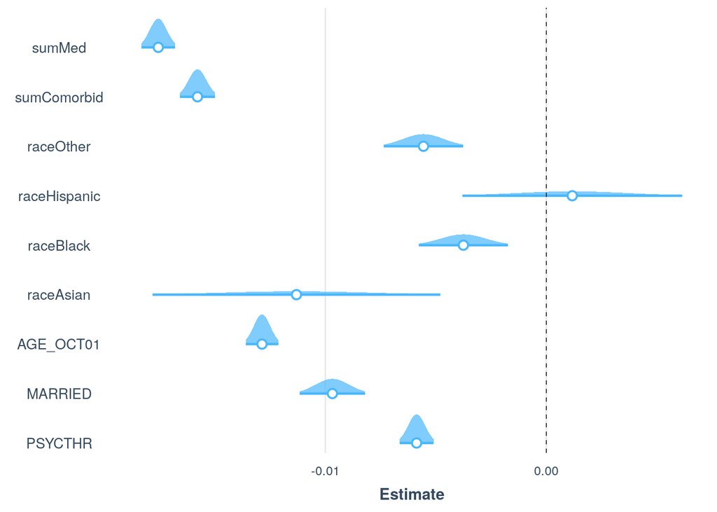

```r
plot_summs(model30, scale = TRUE, plot.distributions = TRUE)
```

```r
export_summs(model30, scale = TRUE, error_format = "[{conf.low}, {conf.high}]", digits = 5)
```

|  | Model 1 |
| --- | --- |
| (Intercept) | 0.05178 *** |
|  | [0.05058, 0.05299] |
| PSYCTHR | -0.00587 *** |
|  | [-0.00664, -0.00511] |
| MARRIED | -0.00968 *** |
|  | [-0.01117, -0.00820] |
| AGE_OCT01 | -0.01287 *** |
|  | [-0.01360, -0.01213] |
| raceAsian | -0.01131 *** |
|  | [-0.01782, -0.00480] |
| raceBlack | -0.00375 *** |
|  | [-0.00577, -0.00174] |
| raceHispanic | 0.00117 |
|  | [-0.00380, 0.00615] |
| raceOther | -0.00556 *** |
|  | [-0.00736, -0.00377] |
| sumComorbid | -0.01579 *** |
|  | [-0.01658, -0.01499] |
| sumMed | -0.01756 *** |
|  | [-0.01832, -0.01680] |
| N | 320073 |
| AIC | -105384.45426 |
| BIC | -105267.01492 |
| Pseudo R2 | -0.06603 |
| *** p < 0.001; ** p < 0.01; * p < 0.05. |  |

Now we will omit those who didn’t have first visit at all and look at the data with time to first visit.

```r
medicatedVa_datFirstV <-  subset(medicatedVa_dat, !is.na(medicatedVa_dat$MHFUFRST))
307798/330772
```

```
## [1] 0.9305443
```

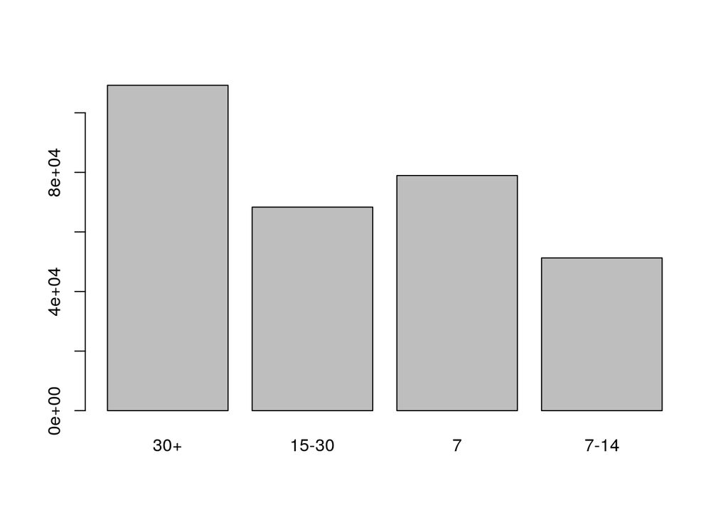

```r
medicatedVa_datFirstV$timeTofV <- factor(case_when(medicatedVa_datFirstV$MHFUFRST<=7 ~ "7", medicatedVa_datFirstV$MHFUFRST > 7 & medicatedVa_datFirstV$MHFUFRST <= 14 ~ "7-14", medicatedVa_datFirstV$MHFUFRST>14 & medicatedVa_datFirstV$MHFUFRST<=30 ~ "15-30", TRUE ~ "30+"))
medicatedVa_datFirstV$timeTofV <- relevel(medicatedVa_datFirstV$timeTofV, "30+")
plot(medicatedVa_datFirstV$timeTofV)
```

```r
summary(medicatedVa_datFirstV$MHFUFRST)
```

```
##    Min. 1st Qu.  Median    Mean 3rd Qu.    Max.
##    1.00    7.00   20.00   39.71   43.00  365.00
```

```r
head(medicatedVa_datFirstV)
```

| PTSDIND | MHPRE_DTE | MHPST_DTE | MHDROPD | MHDROP | OBSRV_PERIOD | MHTOTALL | POSTDXTOT | MHFUFRST | MHPRETOT | MHPOSTYTOT | MHPTSDTOT | MSPRE_DTE | MSPOST_DTE | MSTOTPRE | MSTOTPOST | INDPSY | GRPPSY | FAMPSY | PSYCTHR | TIMEVST | MONTH2 | MONTH4 | MONTH6 | MONTH12 | VATXM | REAL8VST | DEMENT_ALZ | ALC | DRUG | … |
| --- | --- | --- | --- | --- | --- | --- | --- | --- | --- | --- | --- | --- | --- | --- | --- | --- | --- | --- | --- | --- | --- | --- | --- | --- | --- | --- | --- | --- | --- | --- |
| 1.89e+04 |  | 12/1/2011 | 9/27/2012 | 1 | 9/27/2012 | 89 | 60 | 30 | 0 | 88 | 60 |  | 12/13/2011 |  | 12 | 32 | 8 | 0 | 40 | 7.62 | 1 | 1 | 1 | 0 | 1 | 56 | 0 | 0 | 0 | … |
| 1.9e+04 |  | 1/26/2012 | 2/29/2012 | 1 | 2/29/2012 | 4 | 2 | 57 | 0 | 4 | 2 |  | 1/20/2012 |  | 9 | 2 | 0 | 0 | 2 | 34 | 1 | 0 | 0 | 0 | 0 |  | 0 | 0 | 0 | … |
| 1.75e+04 | 12/26/2006 | 12/28/2007 | 2/4/2008 | 1 | 2/4/2008 | 8 | 0 | 8 | 7 | 10 | 0 | 5/8/2007 | 1/14/2008 | 5 | 7 | 8 | 0 | 0 | 8 | 102 | 1 | 1 | 1 | 0 | 0 |  | 0 | 0 | 0 | … |
| 1.89e+04 | 6/8/2011 | 12/28/2011 | 5/14/2012 | 1 | 5/14/2012 | 5 | 4 | 84 | 5 | 4 | 3 | 10/20/2010 | 10/6/2011 | 18 | 18 | 7 | 0 | 0 | 7 | 56.8 | 1 | 1 | 1 | 0 | 0 |  | 0 | 0 | 0 | … |
| 1.89e+04 |  | 12/2/2011 | 2/1/2012 | 1 | 2/1/2012 | 3 | 1 | 24 | 0 | 4 | 1 | 11/17/2010 | 11/25/2011 | 6 | 10 | 1 | 0 | 0 | 1 |  | 1 | 1 | 1 | 0 | 0 |  | 0 | 0 | 0 | … |
| 1.88e+04 | 3/16/2011 | 9/15/2011 | 9/15/2011 | 1 | 9/15/2011 | 2 | 1 | 94 | 2 | 1 | 0 | 8/9/2010 | 7/19/2011 | 7 | 7 | 3 | 0 | 0 | 3 | 63 | 1 | 0 | 0 | 0 | 0 |  | 0 | 0 | 0 | … |

```r
surv_less30firstV <- Surv(time = medicatedVa_datFirstV$MEDTOTDAY, event = medicatedVa_datFirstV$MONTH1)
summary(surv_less30firstV)
```

```
##       time           status
##  Min.   :  0.0   Min.   :0.00000
##  1st Qu.: 31.0   1st Qu.:0.00000
##  Median :119.0   Median :0.00000
##  Mean   :147.5   Mean   :0.04969
##  3rd Qu.:267.0   3rd Qu.:0.00000
##  Max.   :364.0   Max.   :1.00000
##  NA's   :175
```

We can create a Cox Hazard analysis with those variables

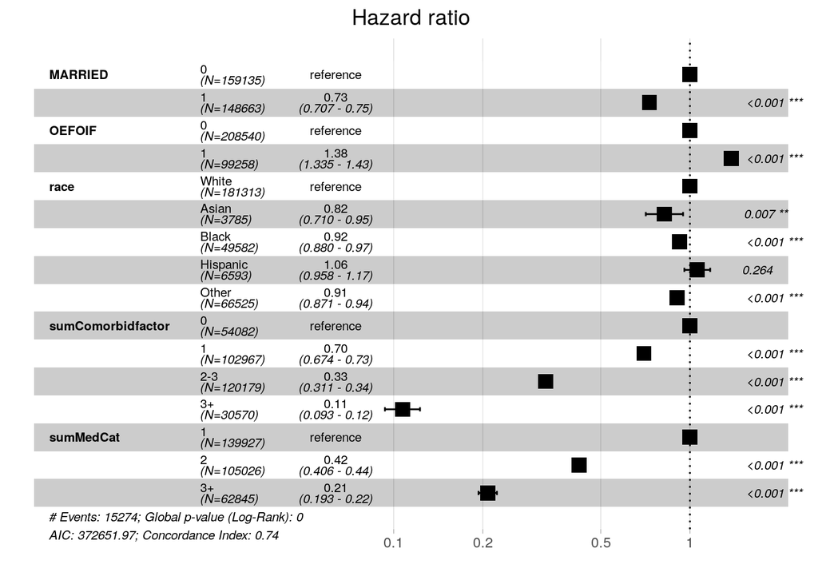

```r
fit.coxphLess30FirstV <- coxph(surv_less30firstV ~ MARRIED + OEFOIF
                    + race + sumComorbidfactor + sumMedCat,
                   data = medicatedVa_datFirstV)
ggforest(fit.coxphLess30FirstV, data = medicatedVa_datFirstV)
```

Lets look at first visit not only in 30 days.

```r
surv_firstV <- Surv(time = medicatedVa_datFirstV$MEDTOTDAY, event = medicatedVa_datFirstV$MHDROP)
summary(surv_firstV)
```

```
##       time           status
##  Min.   :  0.0   Min.   :0.0000
##  1st Qu.: 31.0   1st Qu.:0.0000
##  Median :119.0   Median :1.0000
##  Mean   :147.5   Mean   :0.7037
##  3rd Qu.:267.0   3rd Qu.:1.0000
##  Max.   :364.0   Max.   :1.0000
##  NA's   :175
```

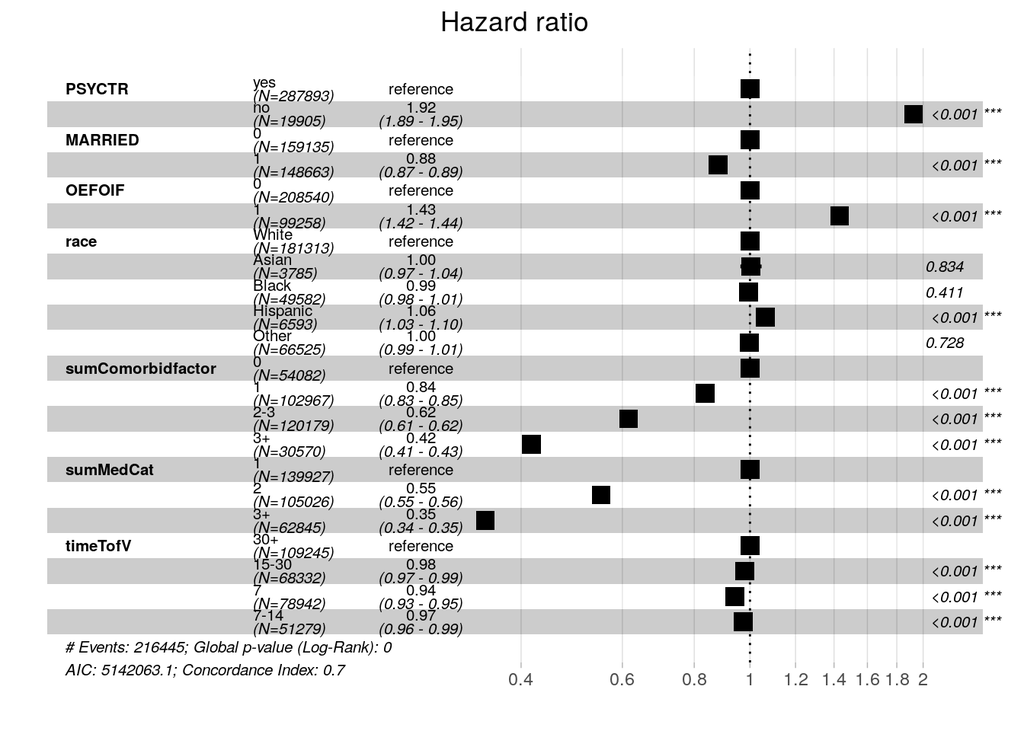

```r
fit.coxphFirstV <- coxph(surv_firstV ~ PSYCTR + MARRIED + OEFOIF + race + sumComorbidfactor + sumMedCat + timeTofV,
                   data = medicatedVa_datFirstV)
ggforest(fit.coxphFirstV, data = medicatedVa_datFirstV)
```

Now we go to antidepressants:

```r
151131/330772
```

```
## [1] 0.4569038
```

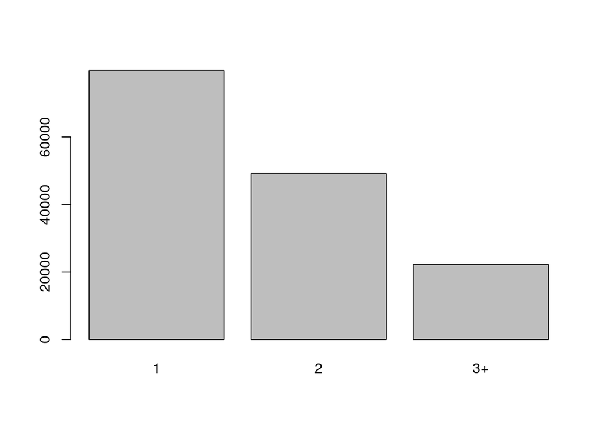

```r
plot(antiDP_dat$sumMedCat)
```

```r
table(antiDP_dat$sumMedCat)
```

```
##
##     1     2    3+
## 79691 49205 22235
```

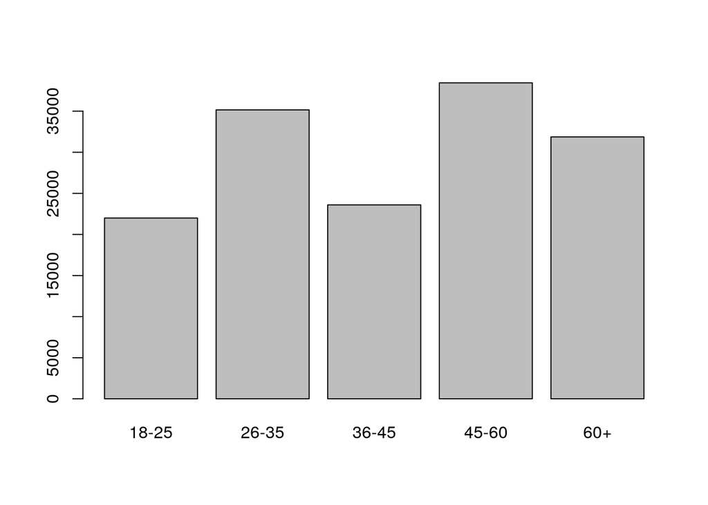

```r
plot(antiDP_dat$ageCat)
```

Now lets do survival analysis

```r
surv_object <- Surv(time = antiDP_dat$MEDTOTDAY, event = antiDP_dat$MHDROP)
summary(surv_object)
```

```
##       time         status
##  Min.   :  0   Min.   :0.0000
##  1st Qu.: 13   1st Qu.:0.0000
##  Median : 94   Median :1.0000
##  Mean   :128   Mean   :0.6779
##  3rd Qu.:228   3rd Qu.:1.0000
##  Max.   :364   Max.   :1.0000
```

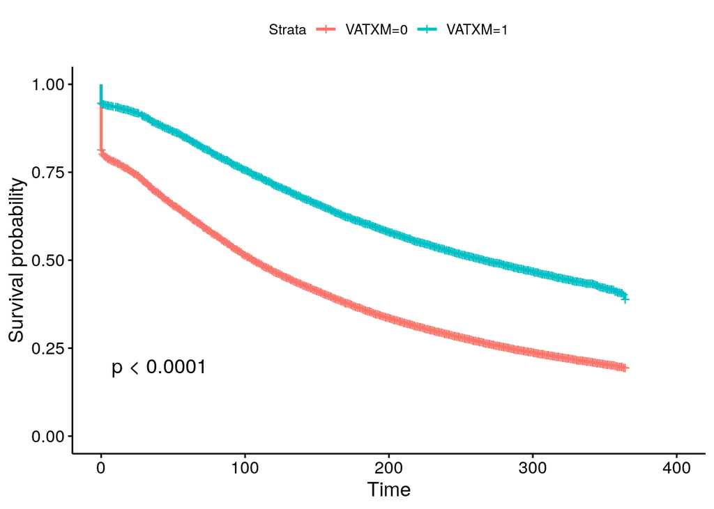

```r
# fitting
fit1 <- survfit(surv_object ~ antiDP_dat$VATXM, data = antiDP_dat) # fit the analysis with gender
#summary(fit1)
ggsurvplot(fit1, data = antiDP_dat, pval = TRUE)
```

Seems like VAXTM is very good. Lets do hazard analysis.

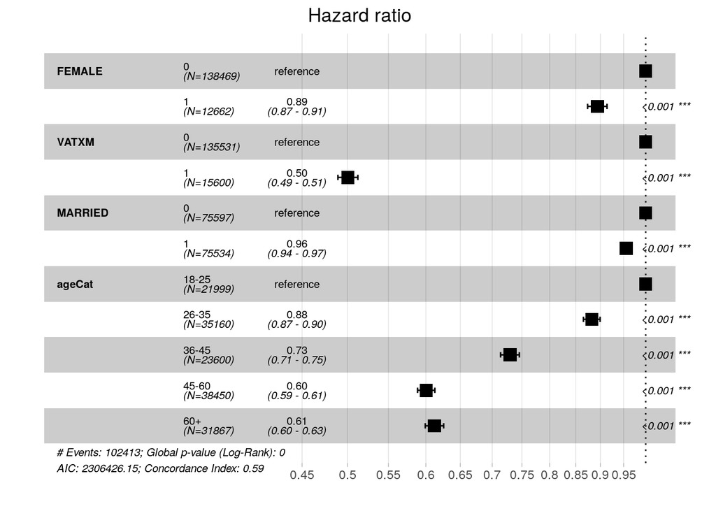

```r
# Hazard analysis
fit.coxph1 <- coxph(surv_object ~ FEMALE  + VATXM + MARRIED + ageCat,
                   data = antiDP_dat)
ggforest(fit.coxph1, data = antiDP_dat)
```

Now we should add comorbidity

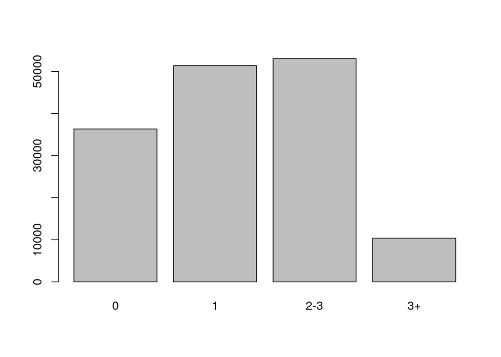

```r
plot(antiDP_dat$sumComorbidfactor)
```

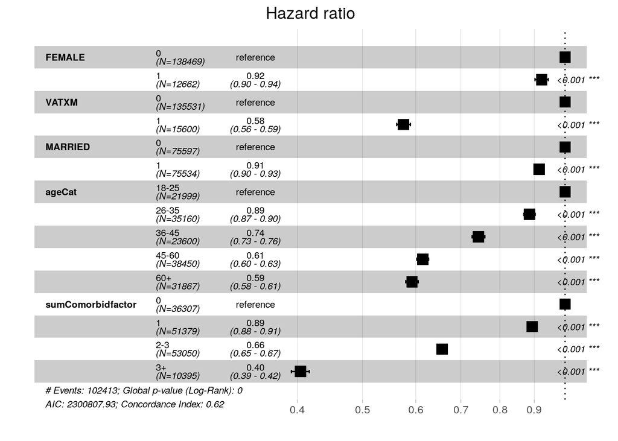

```r
fit.coxph2 <- coxph(surv_object ~ FEMALE  + VATXM + MARRIED + ageCat + sumComorbidfactor,
                   data = antiDP_dat)
ggforest(fit.coxph2, data = antiDP_dat)
```

Lets check only with Anxiety disorder.

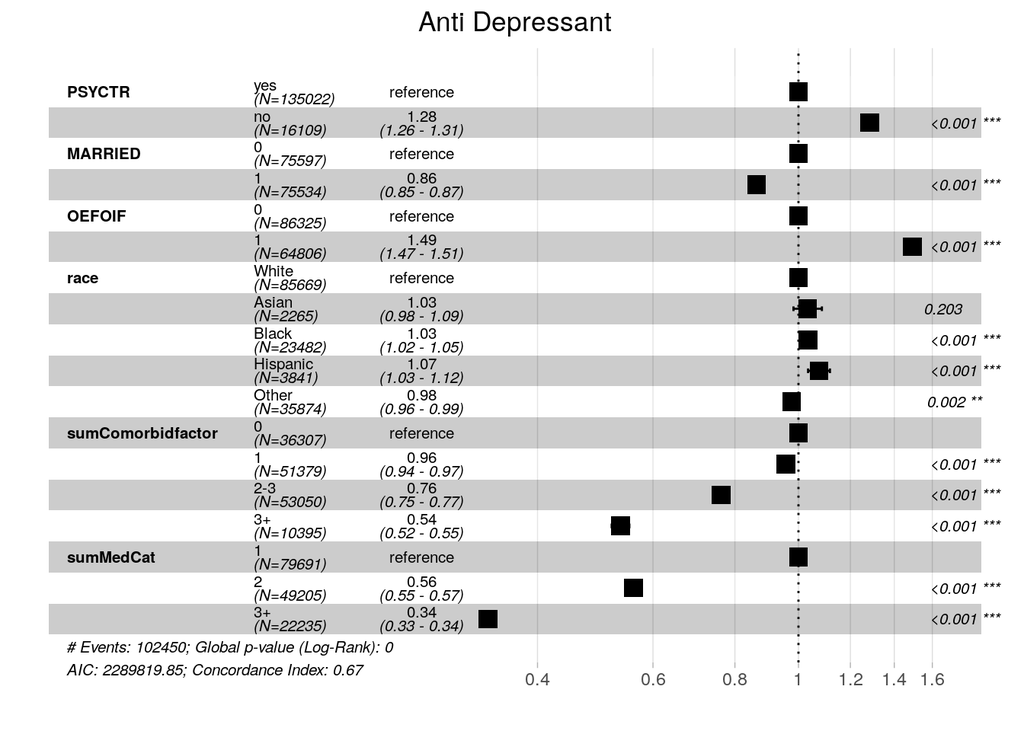

```r
######################################################################
######################################################################
############### ANALYSIS ANTI DEPRESSANTS #################
fit.coxph3 <- coxph(surv_object ~ PSYCTR + MARRIED + OEFOIF + race + sumComorbidfactor + sumMedCat,
                   data = antiDP_dat)
ggforest(fit.coxph3, data = antiDP_dat, main = "Anti Depressant")
```

Lets take anxiolitics now

```r
antiANX_dat <- dplyr::filter(vaDatclean, !is.na(AXSEDHPRXN) & is.na(PREADRX) & is.na(PREAPRX) & is.na(PREAXRX) & is.na(PRESTIRX) & is.na(PREACRX) & is.na(PRELIRX) & is.na(PREOPRX) & is.na(PREPRZRX))
60641/330772
```

```
## [1] 0.1833317
```

```r
surv_objectAnx <- Surv(time = antiANX_dat$MEDTOTDAY, event = antiANX_dat$MHDROP)
fit.coxph4 <- coxph(surv_objectAnx ~ PSYCTR + MARRIED + OEFOIF + race + sumComorbidfactor + sumMedCat,
                   data = antiANX_dat)
summary(fit.coxph4)
```

```
## Call:
## coxph(formula = surv_objectAnx ~ PSYCTR + MARRIED + OEFOIF +
##     race + sumComorbidfactor + sumMedCat, data = antiANX_dat)
##
##   n= 60641, number of events= 37373
##
##                           coef exp(coef)  se(coef)       z Pr(>|z|)
## PSYCTRno              0.153294  1.165667  0.019021   8.059 7.67e-16 ***
## MARRIED1             -0.138309  0.870829  0.010573 -13.081  < 2e-16 ***
## OEFOIF1               0.411936  1.509738  0.010589  38.903  < 2e-16 ***
## raceAsian             0.009295  1.009339  0.043256   0.215    0.830
## raceBlack             0.021964  1.022207  0.016848   1.304    0.192
## raceHispanic          0.038113  1.038849  0.033064   1.153    0.249
## raceOther             0.006517  1.006538  0.012612   0.517    0.605
## sumComorbidfactor1    0.004676  1.004687  0.014217   0.329    0.742
## sumComorbidfactor2-3 -0.232551  0.792509  0.014653 -15.870  < 2e-16 ***
## sumComorbidfactor3+  -0.574571  0.562946  0.024647 -23.312  < 2e-16 ***
## sumMedCat2           -0.921012  0.398116  0.015695 -58.680  < 2e-16 ***
## sumMedCat3+          -1.480105  0.227614  0.018199 -81.327  < 2e-16 ***
## ---
## Signif. codes:  0 '***' 0.001 '**' 0.01 '*' 0.05 '.' 0.1 ' ' 1
##
##                      exp(coef) exp(-coef) lower .95 upper .95
## PSYCTRno                1.1657     0.8579    1.1230    1.2099
## MARRIED1                0.8708     1.1483    0.8530    0.8891
## OEFOIF1                 1.5097     0.6624    1.4787    1.5414
## raceAsian               1.0093     0.9907    0.9273    1.0986
## raceBlack               1.0222     0.9783    0.9890    1.0565
## raceHispanic            1.0388     0.9626    0.9737    1.1084
## raceOther               1.0065     0.9935    0.9820    1.0317
## sumComorbidfactor1      1.0047     0.9953    0.9771    1.0331
## sumComorbidfactor2-3    0.7925     1.2618    0.7701    0.8156
## sumComorbidfactor3+     0.5629     1.7764    0.5364    0.5908
## sumMedCat2              0.3981     2.5118    0.3861    0.4106
## sumMedCat3+             0.2276     4.3934    0.2196    0.2359
##
## Concordance= 0.675  (se = 0.001 )
## Rsquare= 0.162   (max possible= 1 )
## Likelihood ratio test= 10713  on 12 df,   p=<2e-16
## Wald test            = 11471  on 12 df,   p=<2e-16
## Score (logrank) test = 12600  on 12 df,   p=<2e-16
```

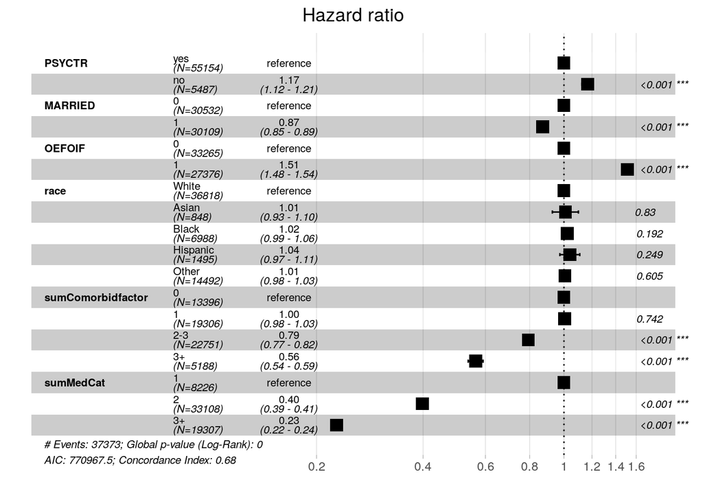

```r
ggforest(fit.coxph4, data = antiANX_dat)
```

Anti psychotics

```r
antiAPX_dat <- dplyr::filter(vaDatclean, !is.na(APSRXN) & is.na(PREADRX) & is.na(PREAPRX) & is.na(PREAXRX) & is.na(PRESTIRX) & is.na(PREACRX) & is.na(PRELIRX) & is.na(PREOPRX) & is.na(PREPRZRX))

28997/330772
```

```
## [1] 0.08766461
```

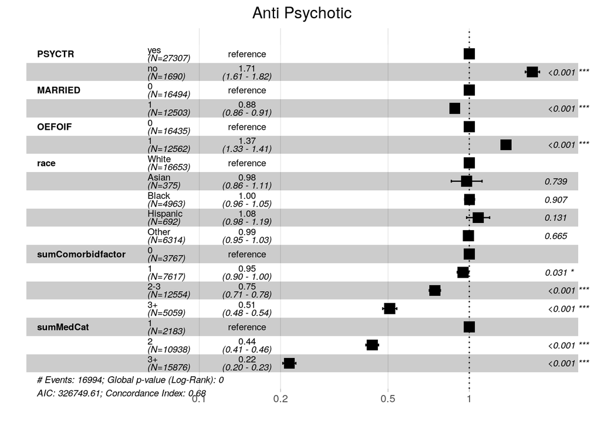

```r
surv_objectApx <- Surv(time = antiAPX_dat$MEDTOTDAY, event = antiAPX_dat$MHDROP)
fit.coxph5 <- coxph(surv_objectApx ~ PSYCTR + MARRIED + OEFOIF + race + sumComorbidfactor + sumMedCat,
                   data = antiAPX_dat)
print(ggforest(fit.coxph5, data = antiAPX_dat, main = "Anti Psychotic"))
```

```r
splots = NULL
splots1 <- ggforest(fit.coxph3, data = antiDP_dat)
splots2 <- ggforest(fit.coxph4, data = antiANX_dat)
splots3 <- ggforest(fit.coxph5, data = antiAPX_dat)
pdf("threplots.pdf")
ggarrange(splots1, splots2, splots3, ncol = 1, nrow = 3, labels = c("A-D","A-X","A-P")) #, widths = c(2,2,2))
dev.off()
```

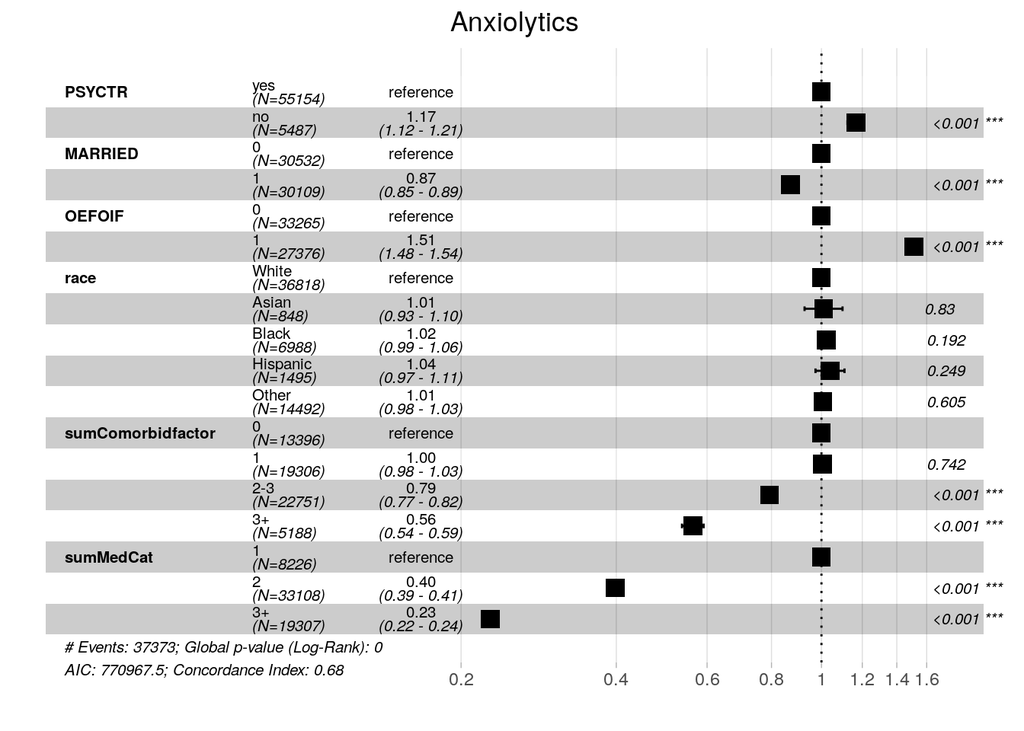

```r
ggforest(fit.coxph4, data = antiANX_dat, main = "Anxiolytics")
```

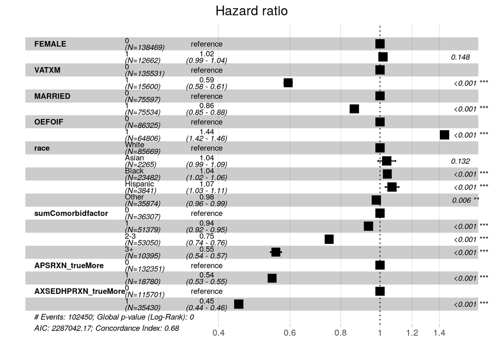

```r
antiDP_dat$APSRXN_trueMore <- factor(case_when(antiDP_dat$APSRXN >1 ~ 1, TRUE ~0))
antiDP_dat$AXSEDHPRXN_trueMore <- factor(case_when(antiDP_dat$AXSEDHPRXN >1 ~ 1, TRUE ~0))
### Including more than one medication ####
fit.coxph5 <- coxph(surv_object ~ FEMALE  + VATXM + MARRIED + OEFOIF + race + sumComorbidfactor + APSRXN_trueMore + AXSEDHPRXN_trueMore,
                   data = antiDP_dat)
ggforest(fit.coxph5, data = antiDP_dat)
```

Lets check MHFUFRST. First meeting after index day

```r
# many NA in first visit after index day.
antiDP_dat_noMFirstNA <- subset(antiDP_dat, !is.na(antiDP_dat$MHFUFRST))
median(antiDP_dat_noMFirstNA$MHFUFRST)
```

```
## [1] 19
```

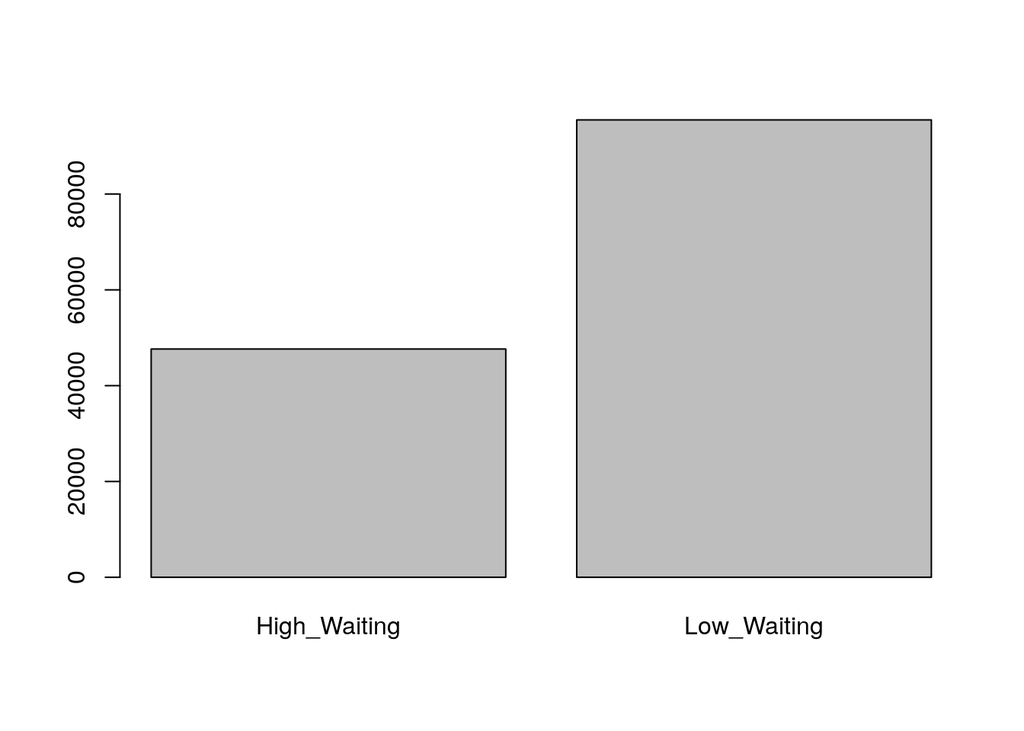

```r
# lets create a median split groups
antiDP_dat_noMFirstNA$firstV <- factor(case_when(antiDP_dat_noMFirstNA$MHFUFRST<=30 ~ "Low_Waiting", antiDP_dat_noMFirstNA$MHFUFRST>30 ~ "High_Waiting"))
plot(antiDP_dat_noMFirstNA$firstV)
```

Now we will create a new analysis, only on this data set.

```r
surv_object_clean <- Surv(time = antiDP_dat_noMFirstNA$MEDTOTDAY, event = antiDP_dat_noMFirstNA$MHDROP)
summary(surv_object)
```

```
##       time         status
##  Min.   :  0   Min.   :0.0000
##  1st Qu.: 13   1st Qu.:0.0000
##  Median : 94   Median :1.0000
##  Mean   :128   Mean   :0.6779
##  3rd Qu.:228   3rd Qu.:1.0000
##  Max.   :364   Max.   :1.0000
```

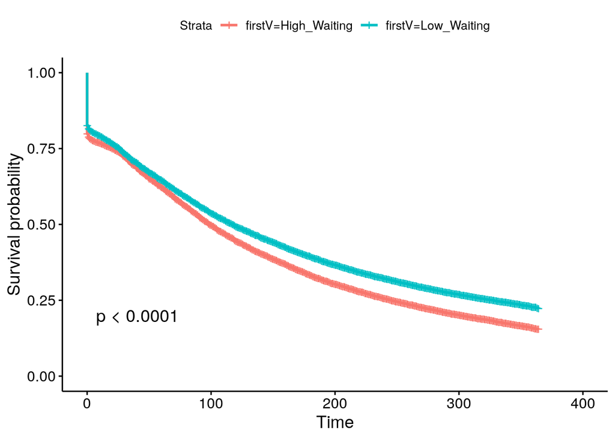

```r
fitClean1<-survfit(surv_object_clean ~ antiDP_dat_noMFirstNA$firstV, data = antiDP_dat_noMFirstNA) # fit the analysis with gender
#summary(fit1)
ggsurvplot(fitClean1, data = antiDP_dat_noMFirstNA, pval = TRUE)
```

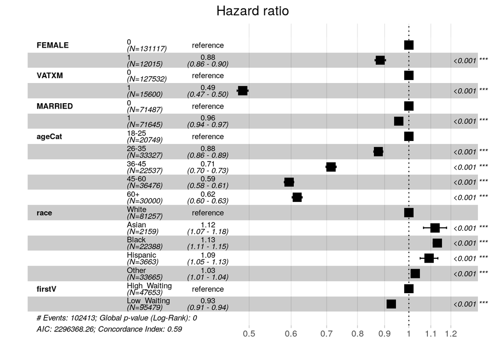

```r
antiDP_dat_noMFirstNA$firstV <- factor(antiDP_dat_noMFirstNA$firstV)
fit.coxphClean <- coxph(surv_object_clean ~ FEMALE  + VATXM + MARRIED + ageCat + race + firstV,
                   data = antiDP_dat_noMFirstNA)
ggforest(fit.coxphClean, data = antiDP_dat_noMFirstNA)
```

Lets check what happens if we cut after 120 days.

```r
# create new timevar with maximum of 120 days
antiDP_dat_noMFirstNA$MEDTOTDAY_max120 <- case_when(antiDP_dat_noMFirstNA$MEDTOTDAY>= 120 ~ 120, TRUE ~ antiDP_dat_noMFirstNA$MEDTOTDAY)
surv_object_120 <- Surv(time = antiDP_dat_noMFirstNA$MEDTOTDAY_max120, event = antiDP_dat_noMFirstNA$MONTH4)
summary(surv_object_120)
```

```
##       time            status
##  Min.   :  0.00   Min.   :0.0000
##  1st Qu.: 18.00   1st Qu.:1.0000
##  Median : 97.00   Median :1.0000
##  Mean   : 73.83   Mean   :0.8927
##  3rd Qu.:120.00   3rd Qu.:1.0000
##  Max.   :120.00   Max.   :1.0000
```